# MDI 343 TP2 k-plus proches voisins, analyse discriminante linéaire et régression logistique

### Régression logistique

#### Méthode discriminative avec régression logistique

#### Question 21 :

Appliquez la classification par régression logistique sur les données _rand_bi*gauss*. Comparer les résultats avec la $LDA$, notamment lorsque une classe est beaucoup plus petite que l’autre (a beaucoup moins d’observations). On parle alors de classes déséquilibrées.

#### On génère le dataset (rand_bi_gauss) pour la régression logistique

```python
X_6_data_rand_bi_gauss, Y_6_data_rand_bi_gauss = source_TP2.rand_bi_gauss(n1=55, n2=3, mu1=[1, 1], mu2=[-1, -1],
                                                 sigmas1=[0.4, 0.8], sigmas2=[0.7, 0.2])
```

#### On affiche la distribution des données

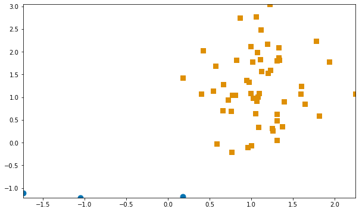

```python
source_TP2.plot_2d(X_6_data_rand_bi_gauss, Y_6_data_rand_bi_gauss)
```

#### On calcul le score de la Regréssion Logistique

```python
reg_log = linear_model.LogisticRegression(solver='lbfgs')
reg_log.fit(X_6_data_rand_bi_gauss, Y_6_data_rand_bi_gauss)

print("Le score de la régression logistique est de :", round(reg_log.score(X_6_data_rand_bi_gauss, Y_6_data_rand_bi_gauss)*100,2),"%")
```

```
Le score de la régression logistique est de : 98.28 %
```

#### On calcul le score de l'Analyse Discriminante Linéaire

```python
lda = LinearDiscriminantAnalysis()
lda.fit(X_6_data_rand_bi_gauss, Y_6_data_rand_bi_gauss)
print("Le score de LDA est de :", round(lda.score(X_6_data_rand_bi_gauss, Y_6_data_rand_bi_gauss)*100,2),"%")
```

```
Le score de LDA est de : 100.0 %
```

#### Question 22 :

À quoi correspond la variable **coef_** du modèle ? **intercept_** ?

- Le paramètre **coef_** correspond aux coefficients du modèle de la regression logistique. Ces coefficients mesurent l'impact des variables explicatives (features) sur la variable à expliquer (la variable cible)
- Le paramètre **intercept_** est une constante correspond à la moyenne de la variable cible *Y* pour *X* = 0

```python
print('Le coefficient de la regression logistiques est : ', reg_log.coef_)
print('L''intercept de la regression logistiques est : ', reg_log.intercept_)
```

```
Le coefficient de la regression logistiques est :  [[1.15438172 1.47923871]]
Lintercept de la regression logistiques est :  [1.69135952]
```

#### Question 23 :

Utiliser la fonction **frontiere_new** pour visualiser la frontière de décision.

#### On trace la frontière de séparation

#### Regression Logisitque

```
(2550, 2)
```

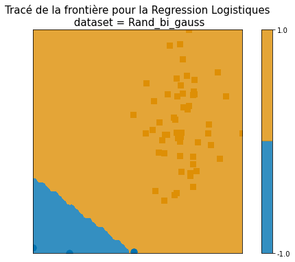

```python
source_TP2.plot_2d(X_6_data_rand_bi_gauss, Y_6_data_rand_bi_gauss)
frontiere_new2(reg_log, X_6_data_rand_bi_gauss, Y_6_data_rand_bi_gauss, w=None, step=50, alpha_choice=1)
plt.title("Tracé de la frontière pour la Regression Logistiques\n dataset = Rand_bi_gauss", size = 15)
```

#### LDA

```
(2550, 2)
```

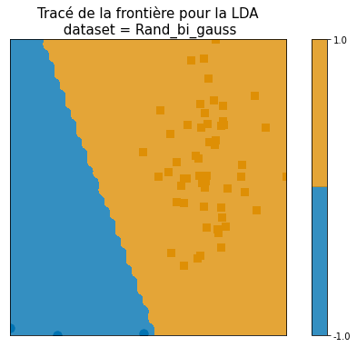

```python
source_TP2.plot_2d(X_6_data_rand_bi_gauss, Y_6_data_rand_bi_gauss)
frontiere_new2(lda, X_6_data_rand_bi_gauss, Y_6_data_rand_bi_gauss, w=None, step=50, alpha_choice=1)
plt.title("Tracé de la frontière pour la LDA\n dataset = Rand_bi_gauss", size = 15)
```

#### Question 24 :

Appliquez la classification par régression logistique à des données issues de la base digits. Comme précédemment, coupez l’échantillon en deux parties de même taille et utilisez la première partie pour l’apprentissage et la deuxième pour tester. Indiquez le taux d’erreur.

```python
# Construction du dataset d'entrainement
print("------------- X_train_digits_bis -------------\n")
X_train_digits_bis = X_digits[: len(X_digits) // 2]
print(X_train_digits_bis)
print("\n")
print("\nTaille de X_train_digits_bis : ", len(X_train_digits_bis))
print("\n")

print("\n------------- y_train_digits_bis -------------\n")
y_train_digits_bis = y_digits[: len(y_digits) // 2]
print(y_train_digits_bis)
print("\n")
print("\nTaille de y_train_digits_bis : ", len(y_train_digits_bis))
print("\n")

# Construction du dataset de test
print("\n------------- X_test_digits_bis -------------\n")
X_test_digits_bis = X_digits[len(X_digits) // 2 :]
print(X_test_digits_bis)
print("\n")
print("\nTaille de X_test_digits_bis : ", len(X_test_digits_bis))
print("\n")

print("\n------------- y_test_digits_bis -------------\n")
y_test_digits_bis = y_digits[len(y_digits) // 2 :]
print(y_test_digits_bis)
print("\n")
print("\nTaille de y_test_digits_bis : ", len(y_test_digits_bis))

print("\n")

print("Taille y_train_digits_bis + y_test_digits_bis = ", len(y_train_digits) + len(y_test_digits))
print("Taille X_train_digits_bis + X_test_digits_bis = ", len(X_train_digits) + len(X_test_digits))
```

[output not shown]

[output cut: 46 more lines]

[output not shown]

#### On applique une classification par régression logisitique sur le dataset digits

```python
reg_log_bis = linear_model.LogisticRegression(solver='liblinear', multi_class='ovr')
reg_log_bis.fit(X_train_digits_bis, y_train_digits_bis)
```

```
LogisticRegression(multi_class='ovr', solver='liblinear')
```

#### On calcul le score de prédiction de la regression logistique sur le dataset digits

```python
score_reg_log = reg_log_bis.score(X_test_digits_bis, y_test_digits_bis)
print("Le score de prédiction de la régression logistiques sur le dataset digit est : ", str(round(score_reg_log * 100, 2)) + "%")
```

```
Le score de prédiction de la régression logistiques sur le dataset digit est :  91.66%
```